# EasyVisa-Adv-ML-Project

### Model Summary

- Validation performance improved after hyperparameter tuning, especially in precision and F1.
- Training performance decreased, indicating reduced overfitting.
- The model still shows mild overfitting, but it is less severe than before.

### Importances

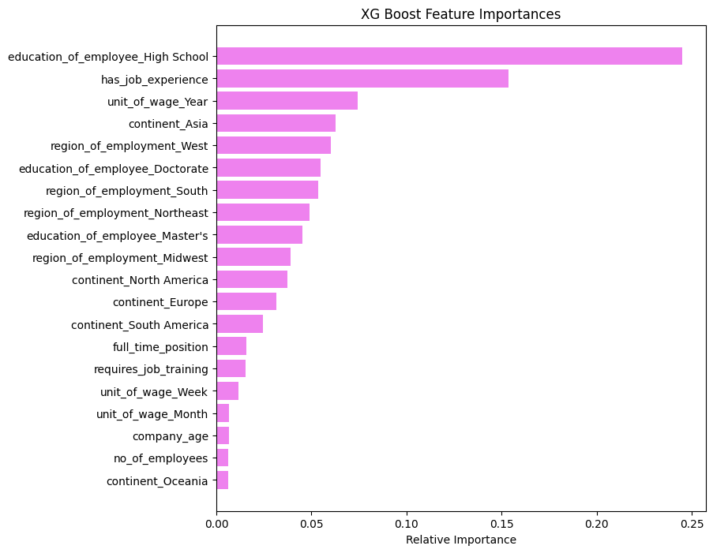

```python
# compute and print the important features
xgb_importances = xg_boost_classifier_tuned.feature_importances_
xgb_indices = np.argsort(xgb_importances)
xgb_feature_names = list(X.columns)

# plot the feature importance
plt.figure(figsize=(8,8))
plt.title('XG Boost Feature Importances')
plt.barh(range(len(xgb_indices)), xgb_importances[xgb_indices], color='violet', align='center')
plt.yticks(range(len(xgb_indices)), [xgb_feature_names[i] for i in xgb_indices])
plt.xlabel('Relative Importance')
plt.show()
```

**Observations**

- XG Boost hyper parameter tuned model considers the employee high school as the important feature for applicants getting visas certified. This could be used in negative filter context. This is followed by Job experience, Wages being yearly and Continent Asia
- It can also be observed the features Job experience, High School Education, Asia continent is in top 6 for all 3 hyper parameter tuned models

# **7. Compare hyperparameter tuned models**

## Listing the models

```python
# Create the matrix to display the techniques and the models with their performance on training and testing data
hpt_model_names = [
  'Ada Boost oversampled',
  'Ada Boost hyperparameter tuned',
  'Gradient Boost oversampled',
  'Gradient Boost hyperparameter tuned',
  'XG Boost oversampled',
  'XG Boost hyperparameter tuned'
]

hpt_models = pd.concat([
	ada_boost_classifier_over_performance,
  ada_boost_classifier_tuned_performance,
	gradient_boost_classifier_over_performance,
	gradient_boost_classifier_tuned_performance,
	xg_boost_classifier_over_performance,
	xg_boost_classifier_tuned_performance
  ], axis =0, keys = hpt_model_names)

hpt_models
```

|  |  |  | Accuracy | Recall | Precision | F1 |
| --- | --- | --- | --- | --- | --- | --- |
| Ada Boost oversampled | Training | 0 | 0.740034 | 0.538240 | 0.742906 | 0.624225 |
|  | Validation | 0 | 0.734609 | 0.469719 | 0.636000 | 0.540357 |
| Ada Boost hyperparameter tuned | Training | 0 | 0.769286 | 0.642681 | 0.746894 | 0.690880 |
|  | Validation | 0 | 0.742458 | 0.546529 | 0.629252 | 0.584980 |
| Gradient Boost oversampled | Training | 0 | 0.769396 | 0.636513 | 0.750727 | 0.688919 |
|  | Validation | 0 | 0.745156 | 0.539143 | 0.637555 | 0.584234 |
| Gradient Boost hyperparameter tuned | Training | 0 | 0.771650 | 0.634731 | 0.756823 | 0.690421 |
|  | Validation | 0 | 0.748590 | 0.538405 | 0.645704 | 0.587193 |
| XG Boost oversampled | Training | 0 | 0.828284 | 0.707374 | 0.839323 | 0.767720 |
|  | Validation | 0 | 0.730684 | 0.508863 | 0.614082 | 0.556543 |
| XG Boost hyperparameter tuned | Training | 0 | 0.773355 | 0.634594 | 0.760762 | 0.691974 |
|  | Validation | 0 | 0.748835 | 0.539143 | 0.646018 | 0.587762 |

## Observations on hyperparameter models

Following are the observations based on the final performance results of the three **hyperparameter-tuned, oversampled models** (**AdaBoost**, **GradientBoost**, and **XGBoost**),

### 1. Best Precision (Validation Set):

- `XGBoost`: **0.646018**
- `GradientBoost`: 0.645704
- `AdaBoost`: 0.629252

**Key Observation:** Precision is the critical metric for EasyVisa, and XGBoost performs best.

### 2. Best F1 Score (Validation Set):

- `XGBoost`: **0.587762**
- `GradientBoost`: 0.587193
- `AdaBoost`: 0.584980

**Key Observation:** F1 score is the next important metric (precision-recall balance), and XGBoost slightly edges out the others.

### 3. Recall (Balance Check)

- `Ada Boost`: 0.546529 (Highest recall)
- `XG Boost`: 0.539143 (Close second)
- `Gradient Boost`: 0.538405 (Lowest)

**Key Observation:** XG Boost maintains reasonable recall while optimizing precision

### 4. Robustness to Overfitting (Gap Analysis):

Training vs Validation F1 gap:

- `AdaBoost`: 0.690880 → 0.584980 → **Gap ≈ 0.106**
- `GradientBoost`: 0.690421 → 0.587193 → **Gap ≈ 0.103**
- `XGBoost`: 0.691974 → 0.587762 → **Gap ≈ 0.104**

**Key Observation:** All models generalize similarly well

## Performance of final model on test data

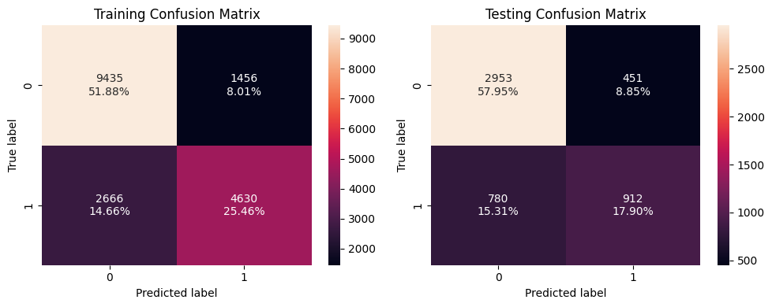

```python
# plot confusion matrices for training, testing data
plot_confusion_matrices_v2(xg_boost_classifier_tuned,
                           X_train_over, y_train_over,
                           X_test, y_test,
                           validation_label = "Testing Confusion Matrix")
```

```python
# compute performance metrics on training data set
xg_boost_classifier_tuned_train_perf = model_performance_classification(
    xg_boost_classifier_tuned, X_train_over, y_train_over
)

# compute performance metrics on testing data
xg_boost_classifier_tuned_test_perf = model_performance_classification(
    xg_boost_classifier_tuned, X_test, y_test
)

# print and compare model performances
xg_boost_classifier_tuned_final_performance = pd.concat([xg_boost_classifier_tuned_train_perf,
                                                         xg_boost_classifier_tuned_test_perf],
                                                        axis=0,
                                                        keys=["Training", "Testing"])
xg_boost_classifier_tuned_final_performance
```

|  |  | Accuracy | Recall | Precision | F1 |
| --- | --- | --- | --- | --- | --- |
| Training | 0 | 0.773355 | 0.634594 | 0.760762 | 0.691974 |
| Testing | 0 | 0.758438 | 0.539007 | 0.669112 | 0.597054 |

### Model performance summary on test data

- Test F1 (0.597) shows a reasonable generalization from training F1 (0.692).
- Precision remains strong on test (0.669), indicating good handling of false positives.
- Recall drops moderately (from 0.635 to 0.539), suggesting some missed positives.
- Overall, the model generalizes well and is balanced for precision focused

# **8. Actionable Insights & Recommendations**

## Key Highlights : Business Recommendations

1. Prioritize Job Experience
2. Implement Strategic Education-Based Filtering
3. Target Asian Applicants in Strategic US Regions
4. Favor Yearly Wage Positions for Higher Success Rates
5. Streamline Operations by Excluding Low-Impact Factors
6. Deploy Model for Strategic OFLC Workload Reduction

## Detailed : Business Recommendations

1. Prioritize Job Experience
   - **Use job experience as a primary positive screening filter** to identify high-probability candidates
   - **Strongly favor applicants with prior job experience** as it's the second-highest predictor (0.15 importance) of visa approval
   - **Deprioritize candidates without work experience** as they show significantly lower approval rates
2. Implement Strategic Education-Based Filtering
   - **Prioritize Bachelor's and Master's degree holders** for positive recommendations as they historically show higher approval rates
   - **Include Doctorate candidates with moderate priority** but focus resources on Bachelor's/Master's applicants first
   - **Use High School education as a negative screening filter** - high model importance (0.24) to it indicates rejection patterns
3. Target Asian Applicants in Strategic US Regions
   - **Focus recruitment and screening efforts on Asian candidates** as they show strong positive correlation (0.06 importance) with approvals
   - **Allocate more resources to Asian applicant screening** to maximize approval success rates
   - **Prioritize applications for West, South, and Northeast regions** which demonstrate moderate predictive importance
4. Favor Yearly Wage Positions for Higher Success Rates
   - **Prioritize applications with annual salary structures** over hourly/weekly positions (0.07 importance)
   - **Use yearly wage as a positive indicator** of stable, full-time roles that align with OFLC approval criteria
   - **Screen out lower-commitment hourly positions** to improve overall approval probability
5. Streamline Operations by Excluding Low-Impact Factors
   - **Remove company size and company age** from primary screening criteria as they show minimal predictive power
   - **Simplify application review process** by focusing only on high-importance features
   - **Reduce screening complexity** to enable faster, more efficient candidate evaluation
6. Deploy Model for Strategic OFLC Workload Reduction
   - **Implement 67% precision model** to pre-filter applications and reduce OFLC manual review burden by ~33%
   - **Use two-tier screening approach**: automated filtering followed by manual review for edge cases
   - **Accept 54% recall limitation** while capturing majority of approvable candidates efficiently
   - **Monitor model performance** and adjust thresholds based on OFLC feedback and approval outcomes

## Model limitations and business considerations

1. Model Interpretability and Trust
   - **Transparency** should be maintained with OFLC stakeholders on key decision factors (education, experience, geography) to ensure accountability
   - **Use model as decision support tool** rather than replacement for human reviewers, especially for complex or high-stakes cases
2. Bias and Fairness Concerns
   - **Model inherits historical OFLC decision biases** which may unfairly impact certain regions, education levels, or wage structures
   - **Ensure compliance** with labor fairness laws and avoid unintentional discrimination in screening recommendations
   - **Regular bias audits** needed to maintain equitable treatment across applicant groups
3. Precision-Recall Trade-offs
   - **67% precision focus** reduces false approvals but increases risk of rejecting qualified candidates
   - **54% recall limitation** means 46% of good candidates may be missed in automated screening
   - **Threshold adjustment flexibility** needed based on OFLC capacity and business priorities
4. Ongoing Model Maintenance and Data Quality Impact
   - **Retrain model every 6-12 months** to adapt to evolving visa policies, labor market changes, and shifting applicant demographics
   - **Feedback loop required** for wrongly rejected candidates to improve future model training
   - **Prevailing wage inconsistencies** and outliers in company data may limit model accuracy
   - **Missing work hour context** in wage calculations could misrepresent true earning potential
   - **Missing valuable predictors** like job type, industry sector, and employer credibility that could improve accuracy

Power Ahead